ASSIGNMENT 2 : DATA WRANGLING

```r
library(tidyverse)
```

```r
library(dplyr)
library(tibble)
library(ggplot2)
```

loading the data

```r
data("msleep")
head(msleep)
```

```
## # A tibble: 6 × 11
##   name    genus vore  order conservation sleep_total sleep_rem sleep_cycle awake
##   <chr>   <chr> <chr> <chr> <chr>              <dbl>     <dbl>       <dbl> <dbl>
## 1 Cheetah Acin… carni Carn… lc                  12.1      NA        NA      11.9
## 2 Owl mo… Aotus omni  Prim… <NA>                17         1.8      NA       7
## 3 Mounta… Aplo… herbi Rode… nt                  14.4       2.4      NA       9.6
## 4 Greate… Blar… omni  Sori… lc                  14.9       2.3       0.133   9.1
## 5 Cow     Bos   herbi Arti… domesticated         4         0.7       0.667  20
## 6 Three-… Brad… herbi Pilo… <NA>                14.4       2.2       0.767   9.6
## # ℹ 2 more variables: brainwt <dbl>, bodywt <dbl>
```

```r
# converting the data to tibble
sleep_data <- as_tibble(msleep)
sleep_data
```

```
## # A tibble: 83 × 11
##    name   genus vore  order conservation sleep_total sleep_rem sleep_cycle awake
##    <chr>  <chr> <chr> <chr> <chr>              <dbl>     <dbl>       <dbl> <dbl>
##  1 Cheet… Acin… carni Carn… lc                  12.1      NA        NA      11.9
##  2 Owl m… Aotus omni  Prim… <NA>                17         1.8      NA       7
##  3 Mount… Aplo… herbi Rode… nt                  14.4       2.4      NA       9.6
##  4 Great… Blar… omni  Sori… lc                  14.9       2.3       0.133   9.1
##  5 Cow    Bos   herbi Arti… domesticated         4         0.7       0.667  20
##  6 Three… Brad… herbi Pilo… <NA>                14.4       2.2       0.767   9.6
##  7 North… Call… carni Carn… vu                   8.7       1.4       0.383  15.3
##  8 Vespe… Calo… <NA>  Rode… <NA>                 7        NA        NA      17
##  9 Dog    Canis carni Carn… domesticated        10.1       2.9       0.333  13.9
## 10 Roe d… Capr… herbi Arti… lc                   3        NA        NA      21
## # ℹ 73 more rows
## # ℹ 2 more variables: brainwt <dbl>, bodywt <dbl>
```

filtering out data to relevant coloumns

```r
select(sleep_data, -c( genus, order))
```

```
## # A tibble: 83 × 9
##    name      vore  conservation sleep_total sleep_rem sleep_cycle awake  brainwt
##    <chr>     <chr> <chr>              <dbl>     <dbl>       <dbl> <dbl>    <dbl>
##  1 Cheetah   carni lc                  12.1      NA        NA      11.9 NA
##  2 Owl monk… omni  <NA>                17         1.8      NA       7    0.0155
##  3 Mountain… herbi nt                  14.4       2.4      NA       9.6 NA
##  4 Greater … omni  lc                  14.9       2.3       0.133   9.1  0.00029
##  5 Cow       herbi domesticated         4         0.7       0.667  20    0.423
##  6 Three-to… herbi <NA>                14.4       2.2       0.767   9.6 NA
##  7 Northern… carni vu                   8.7       1.4       0.383  15.3 NA
##  8 Vesper m… <NA>  <NA>                 7        NA        NA      17   NA
##  9 Dog       carni domesticated        10.1       2.9       0.333  13.9  0.07
## 10 Roe deer  herbi lc                   3        NA        NA      21    0.0982
## # ℹ 73 more rows
## # ℹ 1 more variable: bodywt <dbl>
```

```r
sleep <- select(sleep_data, -c( genus, order))
```

```r
sleep <- mutate(sleep , prop = ((brainwt/bodywt)*100))
sleep
```

```
## # A tibble: 83 × 10
##    name      vore  conservation sleep_total sleep_rem sleep_cycle awake  brainwt
##    <chr>     <chr> <chr>              <dbl>     <dbl>       <dbl> <dbl>    <dbl>
##  1 Cheetah   carni lc                  12.1      NA        NA      11.9 NA
##  2 Owl monk… omni  <NA>                17         1.8      NA       7    0.0155
##  3 Mountain… herbi nt                  14.4       2.4      NA       9.6 NA
##  4 Greater … omni  lc                  14.9       2.3       0.133   9.1  0.00029
##  5 Cow       herbi domesticated         4         0.7       0.667  20    0.423
##  6 Three-to… herbi <NA>                14.4       2.2       0.767   9.6 NA
##  7 Northern… carni vu                   8.7       1.4       0.383  15.3 NA
##  8 Vesper m… <NA>  <NA>                 7        NA        NA      17   NA
##  9 Dog       carni domesticated        10.1       2.9       0.333  13.9  0.07
## 10 Roe deer  herbi lc                   3        NA        NA      21    0.0982
## # ℹ 73 more rows
## # ℹ 2 more variables: bodywt <dbl>, prop <dbl>
```

```r
sleep <- arrange(sleep, sleep_total)
```

ASKING QUESTIONS :

Q1.Does diet affect sleep time ?

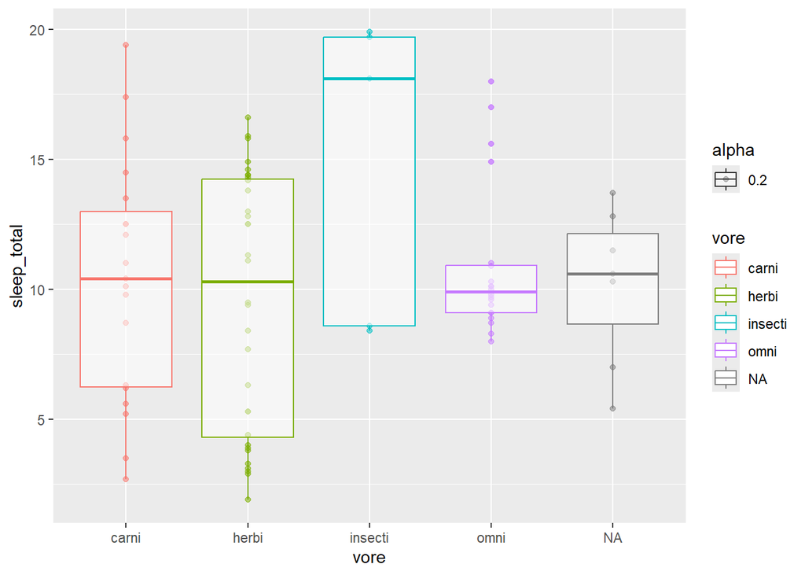

```r
ggplot(sleep, aes(x = vore , y = sleep_total , color = vore, alpha = 0.2)) + geom_point() + geom_boxplot()
```

We can see that insectivores have a higer total sleep than carnivore, herbivore or omnivore , who seem to have nearly similar average sleep.

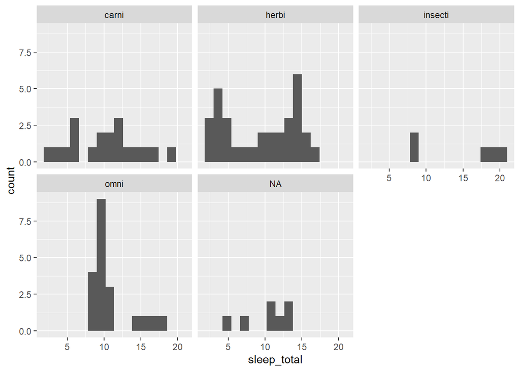

```r
ggplot( data = sleep , aes(x= sleep_total))  + geom_histogram( bins = 16) + facet_wrap(~vore , nrow = 2)
```

we see that in carnivores there is nearly even distribution of total sleep hours, while the omnivores seem to be all close by in a single peak and herbivores with two distinct peaks.

Q2. what is the effect of Body wt. on sleep

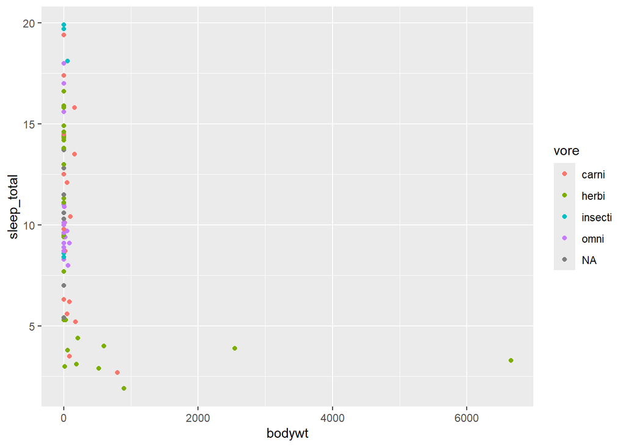

```r
# sleep plotted against weight, the clusters were magnified by limiting a maximum body weight.
ggplot( sleep , aes(x = bodywt, y = sleep_total, color = vore)) + geom_point()
```

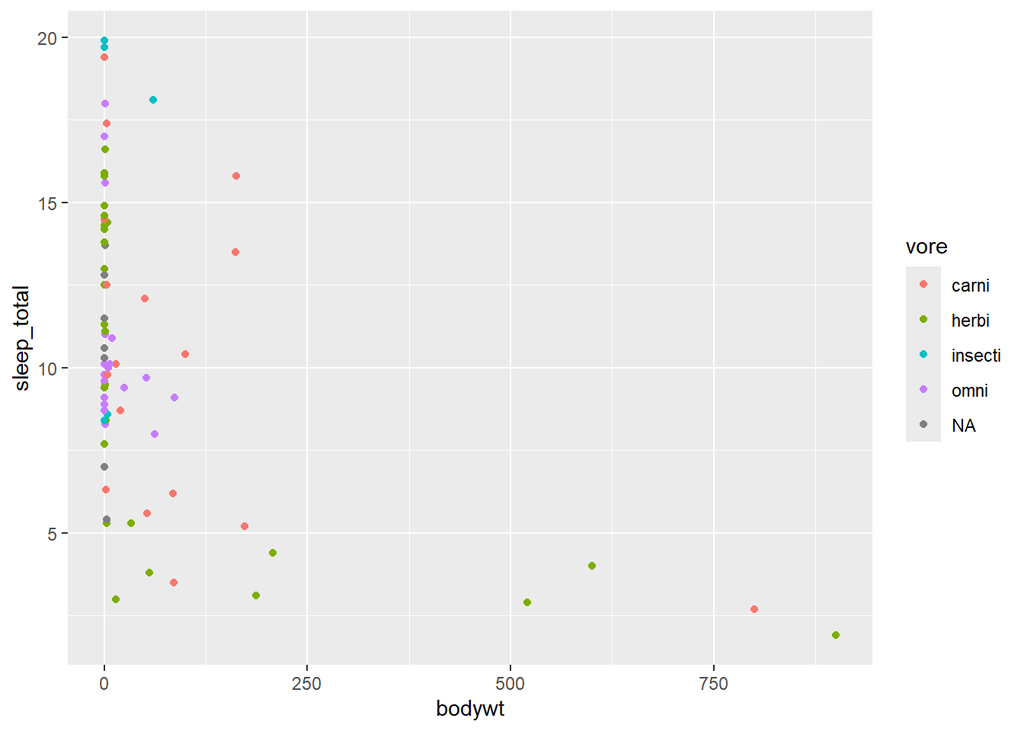

```r
ggplot( filter(sleep,bodywt < 2000) , aes(x = bodywt, y = sleep_total, color = vore)) + geom_point()
```

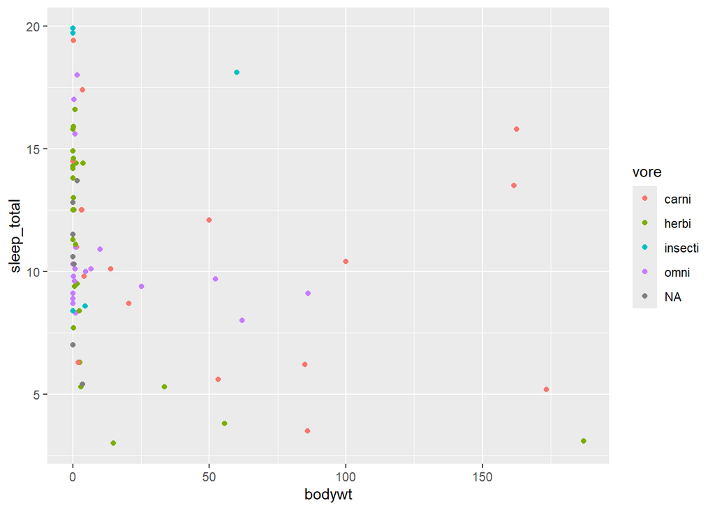

```r
ggplot( filter(sleep,bodywt < 200) , aes(x = bodywt, y = sleep_total, color = vore)) + geom_point()
```

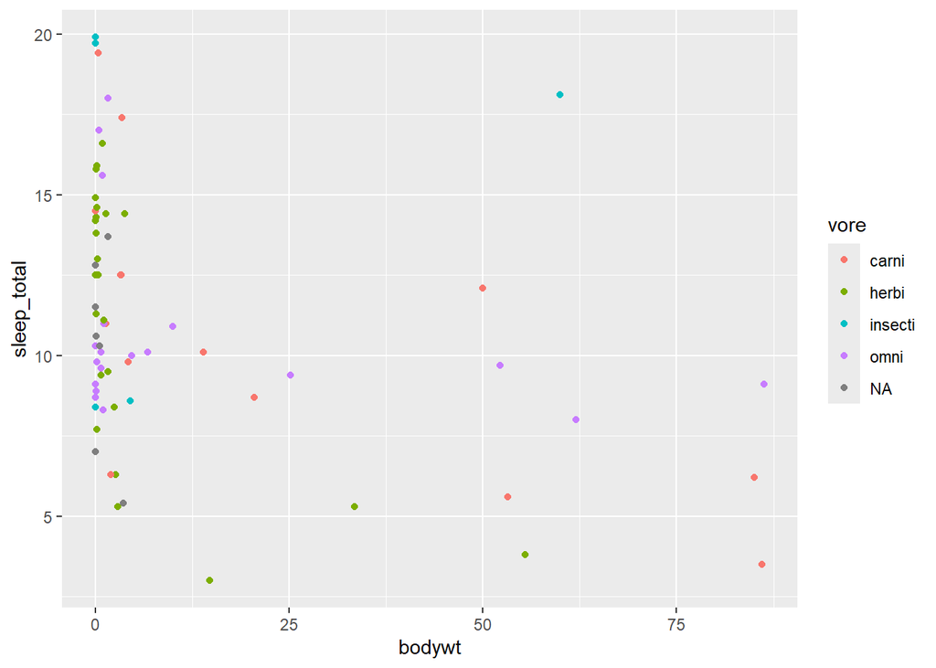

```r
ggplot( filter(sleep,bodywt < 100) , aes(x = bodywt, y = sleep_total, color = vore)) + geom_point()
```

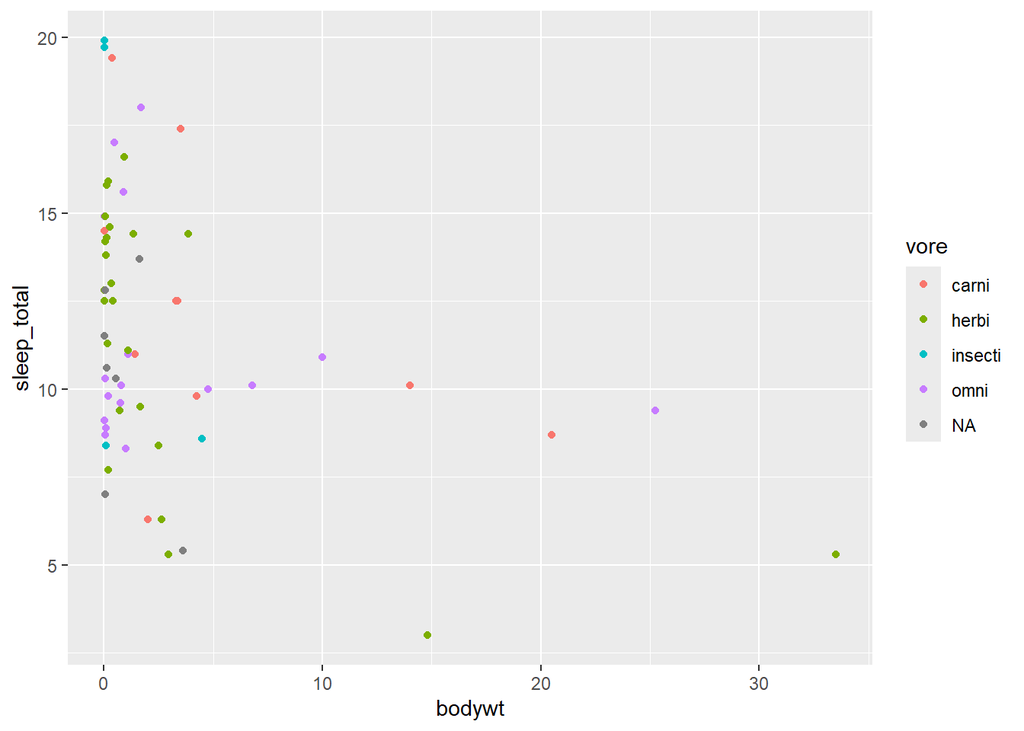

```r
ggplot( filter(sleep,bodywt < 50) , aes(x = bodywt, y = sleep_total, color = vore)) + geom_point()
```

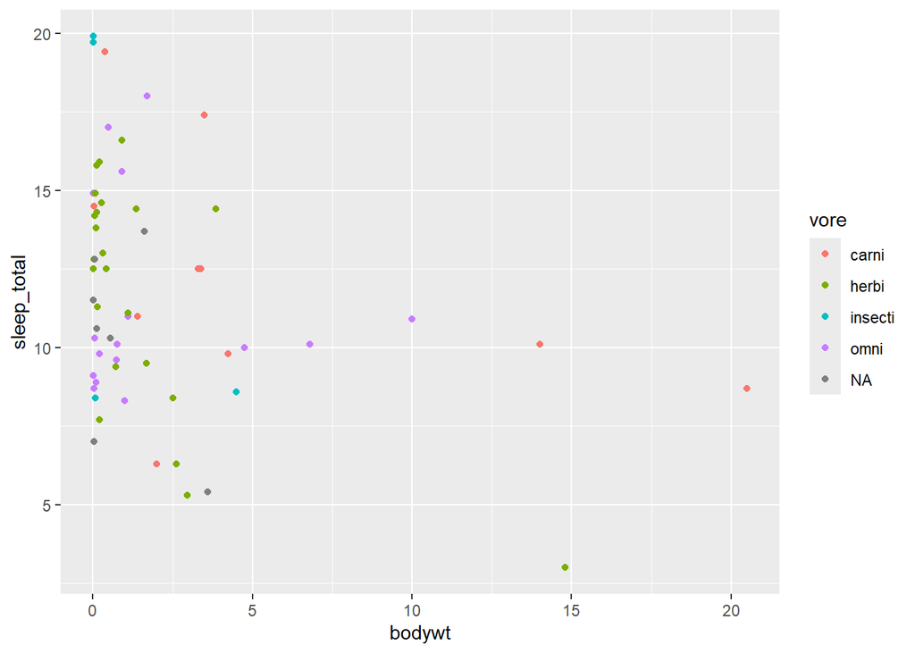

```r
ggplot( filter(sleep,bodywt < 25) , aes(x = bodywt, y = sleep_total, color = vore)) + geom_point()
```

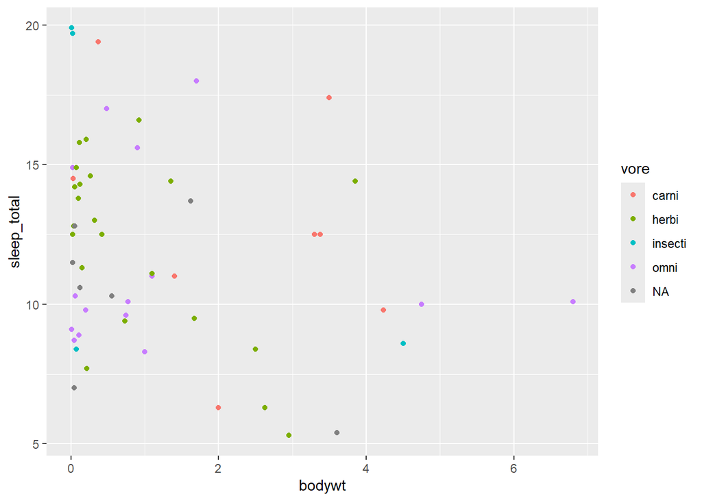

```r
ggplot( filter(sleep,bodywt < 10) , aes(x = bodywt, y = sleep_total, color = vore)) + geom_point()
```

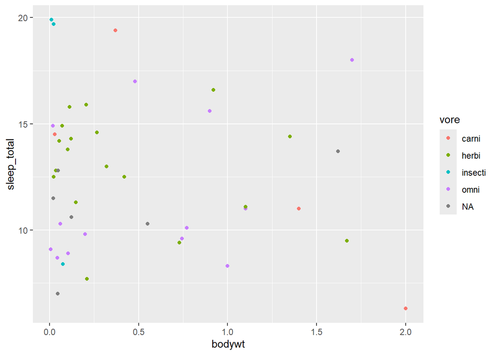

```r
ggplot( filter(sleep,bodywt < 2.5) , aes(x = bodywt, y = sleep_total, color = vore)) + geom_point()
```

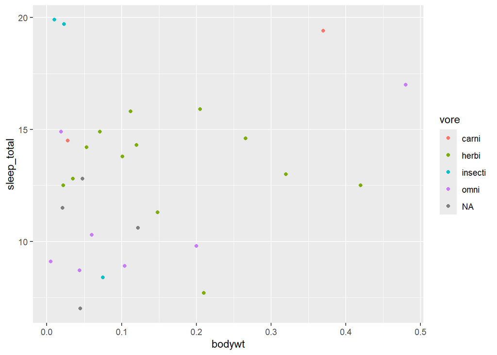

```r
ggplot( filter(sleep,bodywt < 0.5) , aes(x = bodywt, y = sleep_total, color = vore)) + geom_point()
```

this cal also be seen in the head and tail of sleep, the heaviest sleepers are the lighest animals !!

```r
head(select(sleep, name, sleep_total, bodywt ))
```

```
## # A tibble: 6 × 3
##   name             sleep_total bodywt
##   <chr>                  <dbl>  <dbl>
## 1 Giraffe                  1.9  900.
## 2 Pilot whale              2.7  800
## 3 Horse                    2.9  521
## 4 Roe deer                 3     14.8
## 5 Donkey                   3.1  187
## 6 African elephant         3.3 6654
```

```r
tail(select(sleep, name, sleep_total, bodywt ))
```

```
## # A tibble: 6 × 3
##   name                   sleep_total bodywt
##   <chr>                        <dbl>  <dbl>
## 1 Long-nosed armadillo          17.4  3.5
## 2 North American Opossum        18    1.7
## 3 Giant armadillo               18.1 60
## 4 Thick-tailed opposum          19.4  0.37
## 5 Big brown bat                 19.7  0.023
## 6 Little brown bat              19.9  0.01
```

Q3. Does conservation have any effect on sleep duration

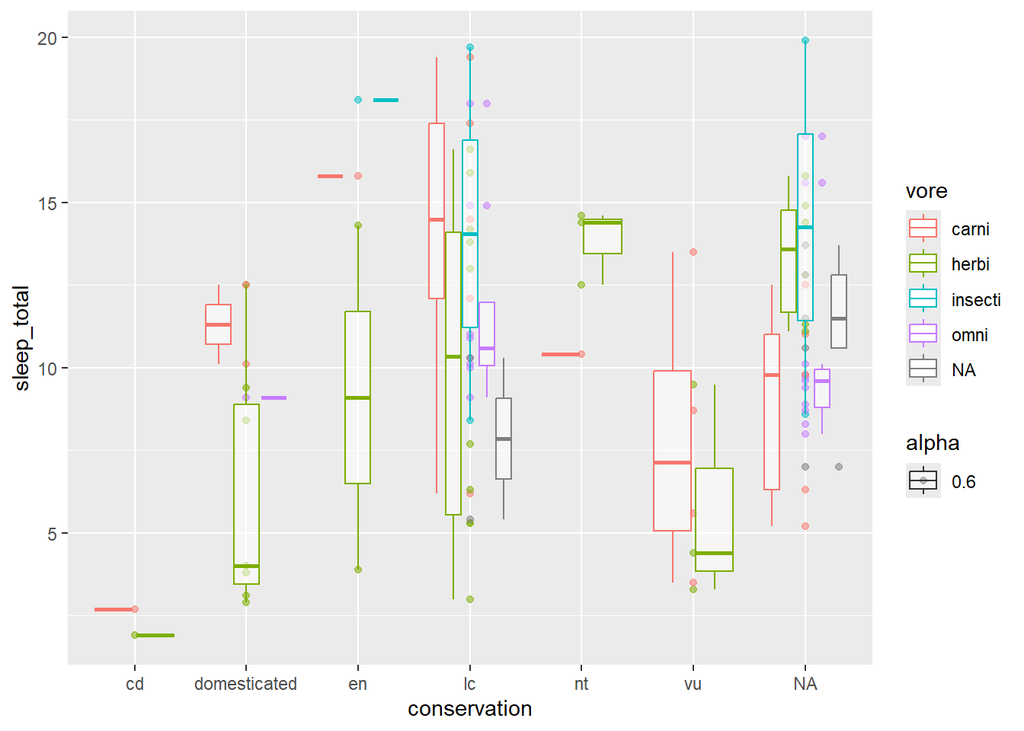

```r
ggplot(sleep, aes(x = conservation , y = sleep_total , color = vore , alpha = 0.6)) + geom_point() + geom_boxplot()
```

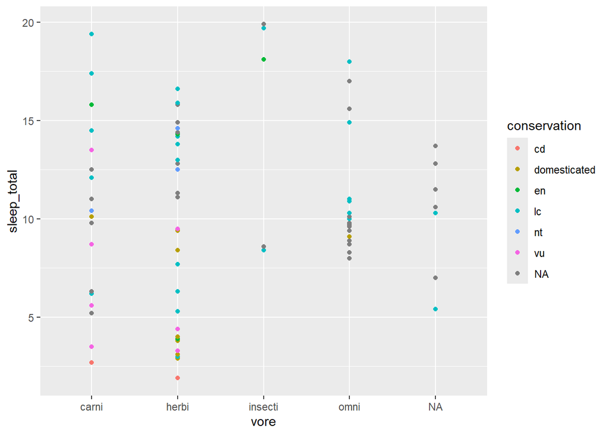

```r
ggplot( sleep , aes(x = vore, y = sleep_total, color = conservation)) + geom_point()
```

there could be many reasons as to why we see this factor: my hypothesis is their environment of constant danger due to being less in number forced them to be more alert.